# MTGA455 Intuit Quickbooks Upgrade

- Team-lead GitLab id: 1530122
- Team-lead GitLab username: rsm2-leduan
- Group number: 4
- Group name: Group 4
- Team member names: Lei Duan, Nehal Jain, Qingqing Long, Xiaochen Li

## Setup

```r
## loading the data
intuit75k_wrk <- readr::read_rds(file.path(find_dropbox(), "MGTA455-2018/data/intuit75k.rds"))
r_data <- list()
r_data[["intuit75k_wrk"]] <- readr::read_rds(file.path(find_dropbox(), "MGTA455-2018/data/intuit75k.rds"))
```

### Part I. Background

Intuit is an American software company that develops financial and tax preparation software and related services for small businesses, accountants and individuals. To increase sales uplift on Quickbook with minimum cost, the firm inserted a modeling effort between the first and second waves of any direct mail campaign. Our objective is to build predictive models to identify high-potential customers in validation sample who have not responded in wave-1 direct mailing campaign and have the tendency to purchase after wave-2 campaign.

### Part II. Methodology

For each model, we established prediction models based on variables on the training set and make prediction on the validation set. The models we used are:

1. Sequential RFM
2. Logistic Regression
3. Naive Bayes
4. Neural Networks

### Part III. Feature Engineering

- Since there are 50 states in the U.S., we created a new variable “zip_bins_50” by redividing “zip” variable into 50 bins and converted it to factor for future exploration.
- Besides, we made interaction variables for version1:upgraded, since we believe in this way, can we make a more specific clients segements to target them better.

```r
## newZipbins
intuit75k_wrk$zip_bins <- as.factor(intuit75k_wrk$zip_bins)
intuit75k_wrk$zip_bins_50 <- as.factor(xtile(as.numeric(intuit75k_wrk$zip), 50))
```

### Part IV. Model Selection and Optimization

#### I) Sequential RFM:

We built a sequential RFM index by selecting `last` variable as recency, use `numords` as frequency and `dollars` as monetary variable and generating quintiles accordingly. Then an average response rate is calculated as predicted probability `prob_rfm` by using `mean(res1 == ‘Yes’)` for each cell. This will be used for the comparison of RFM evaluation with other models is in the later part.

```r
## breakeven
mailing_cost <- 1.41
net_rev <- 60
BE_resp_rate <- mailing_cost / net_rev

# create sequential RFM index
intuit75k_wrk <- intuit75k_wrk %>%
  mutate(rec_sq = xtile(last,5)) %>%
  group_by(rec_sq) %>%
  mutate(freq_sq = xtile(numords,5, rev = T)) %>%
  group_by(rec_sq,freq_sq) %>%
  mutate(mon_sq = xtile(dollars, 5, rev = T),
         rfm_sq = paste0(rec_sq, freq_sq, mon_sq)) %>%
  group_by(rfm_sq) %>%
  mutate(prob_rfm = mean(res1 == "Yes")) %>%
  ungroup()

# split training and test data set
r_data <- list()
r_data[['training']] <- filter(intuit75k_wrk,training == 1)
r_data[['test']] <- filter(intuit75k_wrk,training == 0)
```

#### II) Logistic Regression

Our approach is to first **test on the original variables, add interaction terms among explanatory variables and then consider adding new feature**.

#### III) Naive Bayes

Similar to what we did for logistic regression, we built a full naive bayes model by putting every explanatory variable except “id” and “training”, predicting the response probability in validation set and saving it as “prob_nb”. Then repeated the same procedure and built another three insignificant models where “bizflag”, “sex” were removed separately and simultaneously. Saved the results as “prob_nb_nobiz”, “prob_nb_nosex” and “prob_nb_nobiz_nosex” correspondingly.

Then we compared the four lists of predicted probabilities using ‘evaluate classification’ option in Radiant. It shows that the the model without “bizflag” obtains the highest profit while keeping the same AUC and accuracy with other models *(see summary in **appendix 7**)*. Thus we believe the model without “bizflag” is the optimal when using the original variables in model.

The model even achieved higher profit after changing “zip_bins” to “zip_bins_50” *(see summary in **appendix 8**)*. In conclusion, **the best naive bayes model we adopted is to remove “bizflag” and “zip_bins” from full model and add back “zip_bins_50”** as explanatory variables. The variable “prob_nb_nobiz_zip50” generated from this model will be used to compare with other models in evaluation part.

#### IV) Neural Network

To evaluate the prediction accuracy of model, **bootstrapping** is completed by re-estimating the best NN model 100 times, each time with a different bootstrap sample from original training data. We stored the predicted response probabilities for each sample in a new data.frame and calculated the 5th percentile of the predictions to use as the lower bound on the estimated probability *(see it in **appendix 9**)*.

Based on this parameter, we built the neural network model and saved the results as “prob_nn_lb”, “prob_nn_newzip_lb”(changing “zip_bins” to “zip_bins_50” in model) and “prob_nn_newzip_mean”(changing bins and use 50% as cutoff in predicted probability).

#### Part V. Model Evaluation

We first generated a new variable “mailto_logit” to indicate which is more likely to respond in wave II. The variable will return “True” if the half of “prob_logit_nbf_in” is greater than breakeven rate and vice versa. Based on the “mailto_logit” column, we find that **the expected profit from validation set is $35,007** based on the confusion matrix *(shown in **appendix 11**)*.

$$Profit = 746 * 60 - (746 + 6171) * 1.41 = 35007.03$$

If we scale the profit estimate derived from the best model’s performance in the validation sample to the full set of businesses to target in wave-2, **the profit we anticipate from wave-2 will be $1,248,869** *(see code in **appendix 11**)*.

$$FinalProfit = 35007.03 / 21397 * (801821 - 38487) = 1248869$$

#### Part VI. Conclusion & Learnings:

From this study we can draw the conclusion that:  
* the high margin of selling Quickbooks provides us with the opportunity to target more high-potential customers with less efforts. (i.e, we can be more aggressive given certain condition to pursue more profits).  
* Besides, lower bound predictive approach in both logistic and neural network is too conservative to achieve the highest profit.  
* Sometimes, Neural network may perform quite well, but could be difficult to explain, either. So, one of the way to use it is to take it as a benchmark and then use logistic regression, which is easier to explain and making more business meanings.  
* There is no significant difference in profit between logistic lower bound and logistic bootstrap quantile of 0.05, since bootstrap with quantile of 0.05 seems to work like a manual way to extract the lower bound.

#### Part VII. Appendix

##### 1. Logistic model - Full

```r
## Full model
result <- logistic(
  dataset = "training",
  rvar = "res1",
  evar = c("zip_bins", "sex", "bizflag",
    "numords", "dollars", "last", "sincepurch", "version1", "owntaxprod", "upgraded"
  ),
  lev = "Yes"
)
summary(result)
```

```
Logistic regression (GLM)
Data                 : training
Response variable    : res1
Level                : Yes in res1
Explanatory variables: zip_bins, sex, bizflag, numords, dollars, last, sincepurch, version1, owntaxprod, upgraded
Null hyp.: there is no effect of x on res1
Alt. hyp.: there is an effect of x on res1

                OR coefficient std.error z.value p.value
 (Intercept)            -1.711     0.092 -18.507  < .001 ***
 zip_bins|2  0.148      -1.910     0.110 -17.297  < .001 ***
 zip_bins|3  0.118      -2.141     0.121 -17.710  < .001 ***
 zip_bins|4  0.136      -1.996     0.112 -17.811  < .001 ***
 zip_bins|5  0.116      -2.152     0.120 -17.894  < .001 ***
 zip_bins|6  0.126      -2.068     0.115 -18.043  < .001 ***
 zip_bins|7  0.121      -2.110     0.117 -17.970  < .001 ***
 zip_bins|8  0.131      -2.034     0.114 -17.844  < .001 ***
 zip_bins|9  0.124      -2.086     0.117 -17.856  < .001 ***
 zip_bins|10 0.121      -2.110     0.118 -17.919  < .001 ***
 zip_bins|11 0.128      -2.053     0.116 -17.642  < .001 ***
 zip_bins|12 0.172      -1.763     0.104 -16.871  < .001 ***
 zip_bins|13 0.113      -2.177     0.121 -17.940  < .001 ***
 zip_bins|14 0.131      -2.031     0.115 -17.718  < .001 ***
 zip_bins|15 0.118      -2.135     0.119 -17.892  < .001 ***
 zip_bins|16 0.130      -2.042     0.114 -17.896  < .001 ***
 zip_bins|17 0.130      -2.038     0.114 -17.848  < .001 ***
 zip_bins|18 0.183      -1.698     0.101 -16.745  < .001 ***
 zip_bins|19 0.143      -1.947     0.111 -17.500  < .001 ***
 zip_bins|20 0.124      -2.084     0.116 -17.973  < .001 ***
 sex|Male    0.975      -0.025     0.053  -0.472   0.637
 sex|Unknown 0.964      -0.037     0.076  -0.485   0.628
 bizflag     1.036       0.036     0.049   0.728   0.466
 numords     1.259       0.230     0.019  12.047  < .001 ***
 dollars     1.001       0.001     0.000   4.009  < .001 ***
 last        0.957      -0.044     0.002 -18.064  < .001 ***
 sincepurch  1.002       0.002     0.004   0.467   0.641
 version1    2.113       0.748     0.087   8.583  < .001 ***
 owntaxprod  1.356       0.304     0.103   2.959   0.003 **
 upgraded    2.616       0.962     0.086  11.201  < .001 ***

Signif. codes:  0 '***' 0.001 '**' 0.01 '*' 0.05 '.' 0.1 ' ' 1

Pseudo R-squared: 0.114
Log-likelihood: -8899.946, AIC: 17859.893, BIC: 18125.95
Chi-squared: 2289.751 df(29), p.value < .001
Nr obs: 52,500
```

```r
pred <- predict(result, pred_data = "test", conf_lev = 0.9, se = TRUE)
store(pred, data = "test", name = c("prob_logit", "prob_logit_lb","prob_logit_ub"))

## Model without sex
result <- logistic(
  dataset = "training",
  rvar = "res1",
  evar = c("zip_bins", "bizflag",
           "numords", "dollars", "last", "sincepurch", "version1", "owntaxprod", "upgraded"
  ),
  lev = "Yes"
)
#summary(result)
pred <- predict(result, pred_data = "test")
store(pred, data = "test", name = "prob_logit_ns")

## Model without bizflag
result <- logistic(
  dataset = "training",
  rvar = "res1",
  evar = c("zip_bins", "sex",
           "numords", "dollars", "last", "sincepurch", "version1", "owntaxprod", "upgraded"
  ),
  lev = "Yes"
)
#summary(result)
pred <- predict(result, pred_data = "test", conf_lev = .9, se = TRUE)
store(pred, data = "test", name = c("prob_logit_nbf", "prob_logit_nbf_lb"))

## Model without sincepurch
result <- logistic(
  dataset = "training",
  rvar = "res1",
  evar = c("zip_bins", "sex", "bizflag",
           "numords", "dollars", "last", "version1", "owntaxprod", "upgraded"
  ),
  lev = "Yes"
)
#summary(result)
pred <- predict(result, pred_data = "test")
store(pred, data = "test", name = "prob_logit_nsp")


## Model without sex and bizflag
result <- logistic(
  dataset = "training",
  rvar = "res1",
  evar = c("zip_bins",
           "numords", "dollars", "last", "sincepurch", "version1", "owntaxprod", "upgraded"
  ),
  lev = "Yes"
)
#summary(result)
pred <- predict(result, pred_data = "test")
store(pred, data = "test", name = "prob_logit_nsbf")

## Model without sex and sincepurch
result <- logistic(
  dataset = "training",
  rvar = "res1",
  evar = c("zip_bins",
           "numords", "dollars", "last", "sincepurch", "version1", "owntaxprod", "upgraded"
  ),
  lev = "Yes"
)
#summary(result)
pred <- predict(result, pred_data = "test")
store(pred, data = "test", name = "prob_logit_nssp")

## Model without bizflag and sincepurch
result <- logistic(
  dataset = "training",
  rvar = "res1",
  evar = c("zip_bins",
           "numords", "dollars", "last", "version1", "owntaxprod", "upgraded"
  ),
  lev = "Yes"
)
#summary(result)
pred <- predict(result, pred_data = "test")
store(pred, data = "test", name = "prob_logit_nbfsp")

## Model without sex, bizflag and sincepurch
result <- logistic(
  dataset = "training",
  rvar = "res1",
  evar = c("zip_bins",
           "numords", "dollars", "last", "version1", "owntaxprod", "upgraded"
  ),
  lev = "Yes"
)
#summary(result)
pred <- predict(result, pred_data = "test")
store(pred, data = "test", name = "prob_logit_nsbfsp")
```

##### 2. Logistic model comparison

```r
# 2. AUC, profit, ROME checking for different models
result <- confusion(
  dataset = "test",
  pred = c(
    "prob_logit", "prob_logit_lb",
    "prob_logit_ns", "prob_logit_nbf", "prob_logit_nsp",
    "prob_logit_nsbf", "prob_logit_nssp", "prob_logit_nbfsp", "prob_logit_nsbfsp"
  ),
  rvar = "res1",
  lev = "Yes",
  cost = 1.41,
  margin = 60,
  train = "All"
)
eval_logit <- summary(result)
```

```
Confusion matrix
Data       : test
Results for: All
Predictors : prob_logit, prob_logit_lb, prob_logit_ns, prob_logit_nbf, prob_logit_nsp, prob_logit_nsbf, prob_logit_nssp, prob_logit_nbfsp, prob_logit_nsbfsp
Response   : res1
Level      : Yes in res1
Cost:Margin: 1.41 : 60

 Type         Predictor  TP    FP    TN  FN total   TPR   TNR precision Fscore
  All        prob_logit 978 13326  8071 125 22500 0.887 0.377     0.068  0.127
  All     prob_logit_lb 916 11222 10175 187 22500 0.830 0.476     0.075  0.138
  All     prob_logit_ns 979 13332  8065 124 22500 0.888 0.377     0.068  0.127
  All    prob_logit_nbf 980 13326  8071 123 22500 0.888 0.377     0.069  0.127
  All    prob_logit_nsp 980 13337  8060 123 22500 0.888 0.377     0.068  0.127
  All   prob_logit_nsbf 980 13335  8062 123 22500 0.888 0.377     0.068  0.127
  All   prob_logit_nssp 980 13335  8062 123 22500 0.888 0.377     0.068  0.127
  All  prob_logit_nbfsp 979 13335  8062 124 22500 0.888 0.377     0.068  0.127
  All prob_logit_nsbfsp 979 13335  8062 124 22500 0.888 0.377     0.068  0.127

 Type         Predictor accuracy kappa profit index  ROME contact   AUC
  All        prob_logit    0.402 0.040 38,511 0.997 1.909   0.636 0.754
  All     prob_logit_lb    0.493 0.053 37,845 0.980 2.211   0.539 0.754
  All     prob_logit_ns    0.402 0.040 38,561 0.998 1.911   0.636 0.754
  All    prob_logit_nbf    0.402 0.040 38,629 1.000 1.915   0.636 0.755
  All    prob_logit_nsp    0.402 0.040 38,613 1.000 1.913   0.636 0.754
  All   prob_logit_nsbf    0.402 0.040 38,616 1.000 1.913   0.636 0.755
  All   prob_logit_nssp    0.402 0.040 38,616 1.000 1.913   0.636 0.755
  All  prob_logit_nbfsp    0.402 0.040 38,557 0.998 1.910   0.636 0.755
  All prob_logit_nsbfsp    0.402 0.040 38,557 0.998 1.910   0.636 0.755
```

#### 3. Correlation plot

```r
result <- correlation(
  dataset = "intuit75k_wrk",
  vars = c(
    "zip_bins", "bizflag", "numords", "dollars", "last", "sincepurch",
    "version1", "owntaxprod", "upgraded", "res1"
  )
)
summary(result)
```

```
Correlation
Data     : intuit75k_wrk
Method   : pearson
Variables: zip_bins, bizflag, numords, dollars, last, sincepurch, version1, owntaxprod, upgraded, res1
Null hyp.: variables x and y are not correlated
Alt. hyp.: variables x and y are correlated

Correlation matrix:
           zip_bins bizflag numords dollars last  sincepurch version1 owntaxprod upgraded
bizflag     0.00
numords     0.01     0.00
dollars     0.01     0.00    0.59
last       -0.00    -0.00   -0.13   -0.07
sincepurch -0.00    -0.01    0.00    0.00   -0.00
version1   -0.00    -0.01    0.01    0.00    0.00  0.52
owntaxprod  0.00     0.00    0.12    0.07   -0.02 -0.00      -0.08
upgraded   -0.00    -0.00   -0.00   -0.00   -0.00  0.51      -0.27     0.09
res1        0.06    -0.00   -0.09   -0.07    0.09 -0.08      -0.04    -0.03      -0.07

p.values:
           zip_bins bizflag numords dollars last sincepurch version1 owntaxprod upgraded
bizflag    0.74
numords    0.16     0.96
dollars    0.11     0.58    0.00
last       0.47     0.91    0.00    0.00
sincepurch 0.65     0.15    0.63    0.82    0.75
version1   0.38     0.10    0.12    0.54    0.58 0.00
owntaxprod 0.57     0.21    0.00    0.00    0.00 0.75       0.00
upgraded   0.97     0.40    0.45    0.70    0.96 0.00       0.00     0.00
res1       0.00     0.83    0.00    0.00    0.00 0.00       0.00     0.00       0.00
```

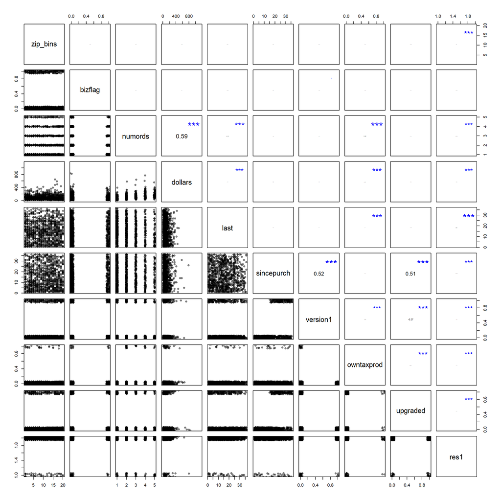

```r
plot(result, n = 1000)
```

##### 4. Logistic model: adding interaction

```r
# 3. Final model without bizflag adding interaction
result <- logistic(
  dataset = "training",
  rvar = "res1",
  evar = c("zip_bins", "sex",
           "numords", "dollars", "last", "sincepurch", "version1", "owntaxprod", "upgraded"
  ),
  lev = "Yes",
  int = "version1:upgraded"
)
pred <- predict(result, pred_data = "test", conf_lev = 0.9, se = TRUE)
store(pred, data = "test", name = c("prob_logit_nbf_in", "prob_logit_nbf_in_lb","prob_logit_nbf_in_ub"))

# compare four models
result <- confusion(
  dataset = "test",
  pred = c(
    "prob_logit_nbf", "prob_logit_nbf_lb", "prob_logit_nbf_in", "prob_logit_nbf_in_lb"
  ),
  rvar = "res1",
  lev = "Yes",
  cost = 1.41,
  margin = 60,
  train = "All"
)
summary(result)
```

```
Confusion matrix
Data       : test
Results for: All
Predictors : prob_logit_nbf, prob_logit_nbf_lb, prob_logit_nbf_in, prob_logit_nbf_in_lb
Response   : res1
Level      : Yes in res1
Cost:Margin: 1.41 : 60

 Type            Predictor  TP    FP    TN  FN total   TPR   TNR precision Fscore
  All       prob_logit_nbf 980 13326  8071 123 22500 0.888 0.377     0.069  0.127
  All    prob_logit_nbf_lb 914 11237 10160 189 22500 0.829 0.475     0.075  0.138
  All    prob_logit_nbf_in 980 13326  8071 123 22500 0.888 0.377     0.069  0.127
  All prob_logit_nbf_in_lb 914 11237 10160 189 22500 0.829 0.475     0.075  0.138

 Type            Predictor accuracy kappa profit index  ROME contact   AUC
  All       prob_logit_nbf    0.402 0.040 38,629 1.000 1.915   0.636 0.755
  All    prob_logit_nbf_lb    0.492 0.053 37,707 0.976 2.201   0.540 0.755
  All    prob_logit_nbf_in    0.402 0.040 38,629 1.000 1.915   0.636 0.755
  All prob_logit_nbf_in_lb    0.492 0.053 37,707 0.976 2.201   0.540 0.755
```

```r
# adding interaction terms does not make much difference, will choose model w/o bizflag as optimal model
```

##### 5. Logistic model: changing zip_bins to zip_bins_50

```r
# change zipbins to zipbins_50
result <- logistic(
  dataset = "training",
  rvar = "res1",
  evar = c("zip_bins_50", "sex",
           "numords", "dollars", "last", "sincepurch", "version1", "owntaxprod", "upgraded"
  ),
  lev = "Yes",
  int = "version1:upgraded"
)
pred <- predict(result, pred_data = "test", conf_lev = 0.9, se = TRUE)
store(pred, data = "test", name = "prob_logit_nbf_in_newbin")

# compare four models
result <- confusion(
  dataset = "test",
  pred = c(
    "prob_logit_nbf_in", "prob_logit_nbf_in_newbin"
  ),
  rvar = "res1",
  lev = "Yes",
  cost = 1.41,
  margin = 60,
  train = "All"
)
summary(result)
```

```
Confusion matrix
Data       : test
Results for: All
Predictors : prob_logit_nbf_in, prob_logit_nbf_in_newbin
Response   : res1
Level      : Yes in res1
Cost:Margin: 1.41 : 60

 Type                Predictor  TP    FP   TN  FN total   TPR   TNR precision Fscore
  All        prob_logit_nbf_in 980 13326 8071 123 22500 0.888 0.377     0.069  0.127
  All prob_logit_nbf_in_newbin 964 12749 8648 139 22500 0.874 0.404     0.070  0.130

 Type                Predictor accuracy kappa profit index  ROME contact   AUC
  All        prob_logit_nbf_in    0.402 0.040 38,629 1.000 1.915   0.636 0.755
  All prob_logit_nbf_in_newbin    0.427 0.043 38,505 0.997 1.991   0.609 0.762
```

##### 6. Logistic model: bootstrapping

```r
#----------------------------------------- Run on server------------------------------------------
# library(radiant)
# intuit75k_wrk <- readr::read_rds("intuit75k.rds")
# intuit75k_wrk$zip_bins <- as.factor(intuit75k_wrk$zip_bins)
# mailing_cost <- 1.41
# net_rev <- 60
# BE_resp_rate <- mailing_cost / net_rev
# training <- filter(intuit75k_wrk,training == 1)
# test <- filter(intuit75k_wrk,training == 0)
#
# #################################################################################################
# r_data <- list()
# r_data[["intuit75k_wrk"]] <- intuit75k_wrk
# r_data[["test"]] <- test
# r_data[["training"]] <- training
#
# logit_result <- data.frame(matrix(NA, nrow = 22500, ncol = 101))
# logit_result[[1]] <- test[["id"]]
# for (i in 1:100){
#   dat <- sample_n(training,52500,replace = TRUE)
#   result <- logistic(
#     dataset = dat,
#     rvar = "res1",
#     evar = c(
#       "zip_bins", "sex","numords", "dollars", "last", "sincepurch",
#       "version1", "owntaxprod", "upgraded"
#     ),
#     lev = "Yes",
#     int = "version1:upgraded"
#   )
#   logit_result[[i+1]] <- predict(result, pred_data = test)$Prediction
# }
#
# logit_result$prob_nbiz_int_bt <- apply(logit_result[,2:101],1,quantile,probs = 0.05)
# logit_result <- logit_result %>% select(id = X1, prob_nbiz_int_bt)
logit_result <- readRDS("logit_result.rds")
r_data[['test']]$prob_logit_nbf_int_bt_lb <- logit_result$prob_nbiz_int_bt
```

##### 7. Naive Bayes: testing on orginal variables

```r
# Full model
result <- nb(
  dataset = "training",
  rvar = "res1",
  evar = c(
    "zip_bins", "sex", "bizflag", "numords", "dollars", "last",
    "sincepurch", "version1", "owntaxprod", "upgraded"
  )
)
summary(result)
```

```
Naive Bayes Classifier
Data                 : training
Response variable    : res1
Levels               : Yes, No in res1
Explanatory variables: zip_bins, sex, bizflag, numords, dollars, last, sincepurch, version1, owntaxprod, upgraded
Laplace              : 0
Nr obs               : 52,500

A-priori probabilities:
res1
  Yes    No
0.048 0.952

Conditional probabilities (categorical) or means & st.dev (numeric):
     zip_bins
res1      1     2     3     4     5     6     7     8     9    10    11    12    13    14    15    16    17    18    19    20
  Yes 0.231 0.044 0.035 0.042 0.035 0.040 0.038 0.040 0.038 0.037 0.038 0.051 0.034 0.040 0.036 0.040 0.040 0.056 0.043 0.039
  No  0.042 0.050 0.050 0.050 0.051 0.051 0.052 0.051 0.050 0.051 0.050 0.050 0.051 0.050 0.050 0.051 0.050 0.051 0.050 0.050

     sex
res1  Female  Male Unknown
  Yes  0.212 0.662   0.126
  No   0.210 0.662   0.128

     bizflag
res1   mean st.dev
  Yes 0.253  0.435
  No  0.244  0.429

     numords
res1   mean st.dev
  Yes 2.568  1.436
  No  2.046  1.224

     dollars
res1     mean  st.dev
  Yes 117.000 103.241
  No   91.467  79.422

     last
```

[output cut: 8 more lines]

```

     version1
res1   mean st.dev
  Yes 0.285  0.451
  No  0.210  0.407

     owntaxprod
res1   mean st.dev
  Yes 0.049  0.216
  No  0.028  0.164

     upgraded
res1   mean st.dev
  Yes 0.335  0.472
  No  0.201  0.401
```

```r
pred <- predict(result, pred_data = "test")
store(pred, data = "test", name = "prob_nb")

# full - bizflag
result <- nb(
  dataset = "training",
  rvar = "res1",
  evar = c(
    "zip_bins", "sex", "numords", "dollars", "last",
    "sincepurch", "version1", "owntaxprod", "upgraded"
  )
)
pred <- predict(result, pred_data = "test")
store(pred, data = "test", name = "prob_nb_nobiz")

# full - biz - sex
result <- nb(
  dataset = "training",
  rvar = "res1",
  evar = c(
    "zip_bins", "numords", "dollars", "last",
    "sincepurch", "version1", "owntaxprod", "upgraded"
  )
)
pred <- predict(result, pred_data = "test")
store(pred, data = "test", name = "prob_nb_nobiz_nosex")

# Full model - sex
result <- nb(
  dataset = "training",
  rvar = "res1",
  evar = c(
    "zip_bins", "bizflag", "numords", "dollars", "last",
    "sincepurch", "version1", "owntaxprod", "upgraded"
  )
)
pred <- predict(result, pred_data = "test")
store(pred, data = "test", name = "prob_nb_nosex")

# compare model performance
result <- confusion(
  dataset = "test",
  pred = c(
    "prob_nb", "prob_nb_nobiz", "prob_nb_nobiz_nosex",
    "prob_nb_nosex"
  ),
  rvar = "res1",
  lev = "Yes",
  cost = 1.41,
  margin = 60,
  train = "All"
)
eval_nb <- summary(result)
```

```
Confusion matrix
Data       : test
Results for: All
Predictors : prob_nb, prob_nb_nobiz, prob_nb_nobiz_nosex, prob_nb_nosex
Response   : res1
Level      : Yes in res1
Cost:Margin: 1.41 : 60

 Type           Predictor  TP   FP    TN  FN total   TPR   TNR precision Fscore
  All             prob_nb 852 9205 12192 251 22500 0.772 0.570     0.085  0.153
  All       prob_nb_nobiz 853 9216 12181 250 22500 0.773 0.569     0.085  0.153
  All prob_nb_nobiz_nosex 853 9219 12178 250 22500 0.773 0.569     0.085  0.153
  All       prob_nb_nosex 852 9206 12191 251 22500 0.772 0.570     0.085  0.153

 Type           Predictor accuracy kappa profit index  ROME contact   AUC
  All             prob_nb    0.580 0.071 36,940 0.999 2.605   0.447 0.729
  All       prob_nb_nobiz    0.579 0.071 36,983 1.000 2.605   0.448 0.729
  All prob_nb_nobiz_nosex    0.579 0.071 36,978 1.000 2.604   0.448 0.729
  All       prob_nb_nosex    0.580 0.071 36,938 0.999 2.605   0.447 0.729
```

```r
# prob_nb_nobiz is slightly better on profit, so we choose prob_nb_nobiz as the best estimator
# among naive bayes.
```

##### 8. Naive Bayes: changing zip_bins to zip_bins_50

```r
# Also we want to test if zip_bins_50 is better than zipbins
# full - bizflag - change zipbins to zipbins_50
result <- nb(
  dataset = "training",
  rvar = "res1",
  evar = c(
    "zip_bins_50", "sex", "numords", "dollars", "last",
    "sincepurch", "version1", "owntaxprod", "upgraded"
  )
)
pred <- predict(result, pred_data = "test")
store(pred, data = "test", name = "prob_nb_nobiz_zip50")

# chechk result
result <- confusion(
  dataset = "test",
  pred = c(
    "prob_nb_nobiz", "prob_nb_nobiz_zip50"
  ),
  rvar = "res1",
  lev = "Yes",
  cost = 1.41,
  margin = 60,
  train = "All"
)
eval_nb <- summary(result)
```

```
Confusion matrix
Data       : test
Results for: All
Predictors : prob_nb_nobiz, prob_nb_nobiz_zip50
Response   : res1
Level      : Yes in res1
Cost:Margin: 1.41 : 60

 Type           Predictor  TP   FP    TN  FN total   TPR   TNR precision Fscore
  All       prob_nb_nobiz 853 9216 12181 250 22500 0.773 0.569     0.085  0.153
  All prob_nb_nobiz_zip50 849 8937 12460 254 22500 0.770 0.582     0.087  0.156

 Type           Predictor accuracy kappa profit index  ROME contact   AUC
  All       prob_nb_nobiz    0.579 0.071 36,983 0.996 2.605   0.448 0.729
  All prob_nb_nobiz_zip50    0.592 0.074 37,142 1.000 2.692   0.435 0.739
```

```r
# replacing zipbin with zipbins_50 is better. Final model is no bizflag adding zipbins_50
```

##### 9. Neural Network

```r
#----------------------------------------- Run on server------------------------------------------

## 1. choose the best size & decay combination

# for (i in 1:5){
#   size = i
#   for (j in 1:6) {
#     decay = j/2
#     result <- nn(
#       dataset = "training",
#       rvar = "res1",
#       evar = c(
#         "zip_bins","sex","bizflag", "numords", "dollars", "last", "sincepurch",
#         "version1", "owntaxprod", "upgraded"),
#       decay = decay,
#       size = size,
#       lev = "Yes",
#       seed = 1234)
#     pred <- predict(result, pred_data = "intuit75k_wrk")
#     store(pred, data = "intuit75k_wrk", name = paste("nn",i,j/2,sep="_"))
#   }
# }
#
# result <- confusion(
#   dataset = "intuit75k_wrk",
#   pred = colnames(r_data[["intuit75k_wrk"]])[15:43],
#   rvar = "res1",
#   lev = "Yes",
#   cost = 1.41,
#   margin = 60,
#   train = "All"
# )

## 2. use size = 5 & decay = 0.5 as the best combination to predict with bootstrap

# set.seed(1234)
# nn_result <- data.frame(matrix(NA, nrow = 22500, ncol = 101))
# nn_result[[1]] <- test[["id"]]
# for (i in 1:100){
#   dat <- sample_n(training,52500,replace = TRUE)
#   result <- nn(
#     dataset = dat,
#     rvar = "res1",
#     evar = c(
#       "zip_bins_50", "sex","bizflag","numords", "dollars", "last", "sincepurch",
#       "version1", "owntaxprod", "upgraded"
#     ),
#     size = 5,
#     decay = 0.5,
#     lev = "Yes",
#     seed = 1234
#   )
#   nn_result[[i+1]] <- predict(result, pred_data = test)$Prediction
# }
#
# nn_result$prob_nn_lb <- apply(nn_result[,2:101],1,quantile,probs = 0.05)
# nn_result <- nn_result %>% select(id = X1, prob_nn_lb)
#-------------------------------------------------------------------------------------------------
eval_nn.rds <- readRDS("eval_nn.rds")
nn_result <- readRDS("nn_result.rds")
nn_result_newzip <- readRDS("nn_result_newzip.rds")
r_data[['test']]$prob_nn_lb <- nn_result$prob_nn_lb
r_data[['test']]$prob_nn_newzip_lb <- nn_result_newzip$prob_nn_newzip_lb
r_data[['test']]$prob_nn_newzip_mean <- nn_result_newzip$prob_nn_newzip_mean
```

##### 10. Model evaluation

```r
# Evaluation
result <- evalbin(
  dataset = "test",
  pred = c(
    "prob_rfm", "prob_logit_nbf_in","prob_logit_nbf_in_lb","prob_logit_nbf_int_bt_lb",
    "prob_nb_nobiz_zip50","prob_nn_lb","prob_nn_newzip_lb","prob_nn_newzip_mean"
  ),
  rvar = "res1",
  lev = "Yes",
  cost = 1.41,
  margin = 60,
  train = "All"
)
summary(result)
```

```
Evaluate predictions for binary response models
Data        : test
Results for : All
Predictors  : prob_rfm, prob_logit_nbf_in, prob_logit_nbf_in_lb, prob_logit_nbf_int_bt_lb, prob_nb_nobiz_zip50, prob_nn_lb, prob_nn_newzip_lb, prob_nn_newzip_mean
Response    : res1
Level       : Yes in res1
Bins        : 10
Cost:Margin : 1.41 : 60
                     pred bins nr_obs nr_resp resp_rate gains    profit  ROME cum_prop cum_resp cum_resp_rate cum_lift cum_gains
                 prob_rfm    1   2172     260     0.120 0.236 12537.480 4.094    0.097      260         0.120    2.442     0.236
                 prob_rfm    2   2280     166     0.073 0.150 19282.680 3.072    0.198      426         0.096    1.952     0.386
                 prob_rfm    3   2069     145     0.070 0.131 25065.390 2.726    0.290      571         0.088    1.786     0.518
                 prob_rfm    4   2323     125     0.054 0.113 29289.960 2.349    0.393      696         0.079    1.605     0.631
                 prob_rfm    5   2092      91     0.043 0.083 31800.240 2.062    0.486      787         0.072    1.468     0.714
                 prob_rfm    6   2434      76     0.031 0.069 32928.300 1.747    0.594      863         0.065    1.317     0.782
                 prob_rfm    7   1856      69     0.037 0.063 34451.340 1.605    0.677      932         0.061    1.249     0.845
                 prob_rfm    8   2747      72     0.026 0.065 34898.070 1.377    0.799     1004         0.056    1.140     0.910
                 prob_rfm    9   2270      56     0.025 0.051 35057.370 1.228    0.900     1060         0.052    1.068     0.961
                 prob_rfm   10   2257      43     0.019 0.039 34455.000 1.086    1.000     1103         0.049    1.000     1.000
        prob_logit_nbf_in    1   2250     416     0.185 0.377 21787.500 6.868    0.100      416         0.185    3.772     0.377
        prob_logit_nbf_in    2   2250     195     0.087 0.177 30315.000 4.778    0.200      611         0.136    2.770     0.554
        prob_logit_nbf_in    3   2249     127     0.056 0.115 34763.910 3.653    0.300      738         0.109    2.231     0.669
        prob_logit_nbf_in    4   2250      90     0.040 0.082 36991.410 2.915    0.400      828         0.092    1.877     0.751
        prob_logit_nbf_in    5   2251      65     0.029 0.059 37717.500 2.378    0.500      893         0.079    1.619     0.810
        prob_logit_nbf_in    6   2250      55     0.024 0.050 37845.000 1.988    0.600      948         0.070    1.432     0.859
        prob_logit_nbf_in    7   2249      59     0.026 0.053 38213.910 1.721    0.700     1007         0.064    1.304     0.913
        prob_logit_nbf_in    8   2251      40     0.018 0.036 37440.000 1.475    0.800     1047         0.058    1.187     0.949
        prob_logit_nbf_in    9   2250      30     0.013 0.027 36067.500 1.263    0.900     1077         0.053    1.085     0.976
        prob_logit_nbf_in   10   2250      26     0.012 0.024 34455.000 1.086    1.000     1103         0.049    1.000     1.000
     prob_logit_nbf_in_lb    1   2250     419     0.186 0.380 21967.500 6.924    0.100      419         0.186    3.799     0.380
     prob_logit_nbf_in_lb    2   2250     192     0.085 0.174 30315.000 4.778    0.200      611         0.136    2.770     0.554
     prob_logit_nbf_in_lb    3   2249     122     0.054 0.111 34463.910 3.622    0.300      733         0.109    2.215     0.665
     prob_logit_nbf_in_lb    4   2250      97     0.043 0.088 37111.410 2.925    0.400      830         0.092    1.881     0.752
     prob_logit_nbf_in_lb    5   2251      61     0.027 0.055 37597.500 2.370    0.500      891         0.079    1.616     0.808
     prob_logit_nbf_in_lb    6   2250      55     0.024 0.050 37725.000 1.982    0.600      946         0.070    1.429     0.858
     prob_logit_nbf_in_lb    7   2249      65     0.029 0.059 38453.910 1.732    0.700     1011         0.064    1.309     0.917
     prob_logit_nbf_in_lb    8   2251      35     0.016 0.032 37380.000 1.473    0.800     1046         0.058    1.185     0.948
     prob_logit_nbf_in_lb    9   2250      31     0.014 0.028 36067.500 1.263    0.900     1077         0.053    1.085     0.976
     prob_logit_nbf_in_lb   10   2250      26     0.012 0.024 34455.000 1.086    1.000     1103         0.049    1.000     1.000
 prob_logit_nbf_int_bt_lb    1   2250     418     0.186 0.379 21907.500 6.905    0.100      418         0.186    3.790     0.379
```

[output cut: 34 more lines]

```
        prob_nn_newzip_lb    6   2250      61     0.027 0.055 37725.000 1.982    0.600      946         0.070    1.429     0.858
        prob_nn_newzip_lb    7   2249      60     0.027 0.054 38153.910 1.718    0.700     1006         0.064    1.303     0.912
        prob_nn_newzip_lb    8   2251      43     0.019 0.039 37560.000 1.480    0.800     1049         0.058    1.189     0.951
        prob_nn_newzip_lb    9   2250      25     0.011 0.023 35887.500 1.257    0.900     1074         0.053    1.082     0.974
        prob_nn_newzip_lb   10   2250      29     0.013 0.026 34455.000 1.086    1.000     1103         0.049    1.000     1.000
      prob_nn_newzip_mean    1   2250     454     0.202 0.412 24067.500 7.586    0.100      454         0.202    4.116     0.412
      prob_nn_newzip_mean    2   2250     159     0.071 0.144 30435.000 4.797    0.200      613         0.136    2.779     0.556
      prob_nn_newzip_mean    3   2249     125     0.056 0.113 34763.910 3.653    0.300      738         0.109    2.231     0.669
      prob_nn_newzip_mean    4   2250      89     0.040 0.081 36931.410 2.911    0.400      827         0.092    1.875     0.750
      prob_nn_newzip_mean    5   2251      72     0.032 0.065 38077.500 2.400    0.500      899         0.080    1.630     0.815
      prob_nn_newzip_mean    6   2250      59     0.026 0.053 38445.000 2.020    0.600      958         0.071    1.448     0.869
      prob_nn_newzip_mean    7   2249      50     0.022 0.045 38273.910 1.724    0.700     1008         0.064    1.306     0.914
      prob_nn_newzip_mean    8   2251      42     0.019 0.038 37620.000 1.482    0.800     1050         0.058    1.190     0.952
      prob_nn_newzip_mean    9   2250      28     0.012 0.025 36127.500 1.265    0.900     1078         0.053    1.086     0.977
      prob_nn_newzip_mean   10   2250      25     0.011 0.023 34455.000 1.086    1.000     1103         0.049    1.000     1.000
```

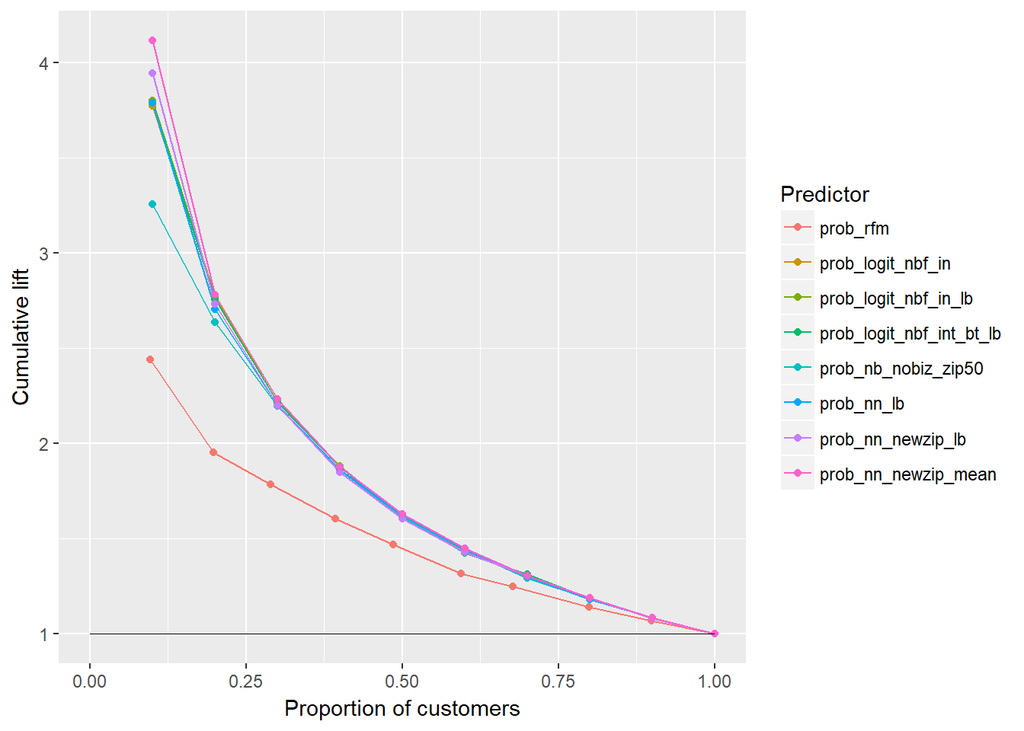

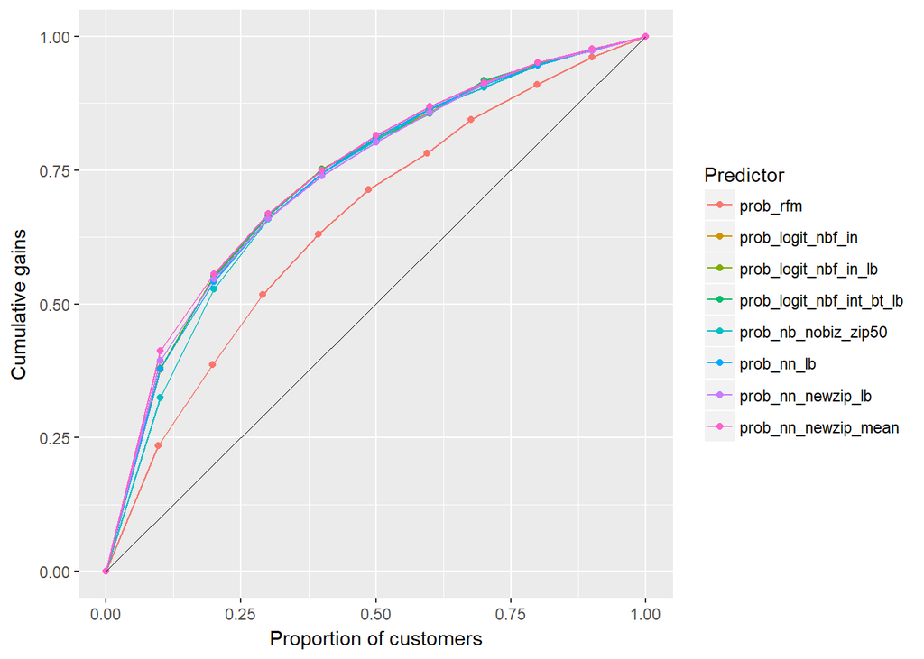

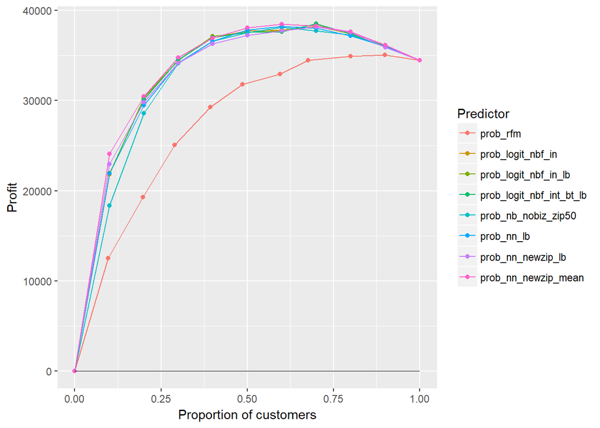

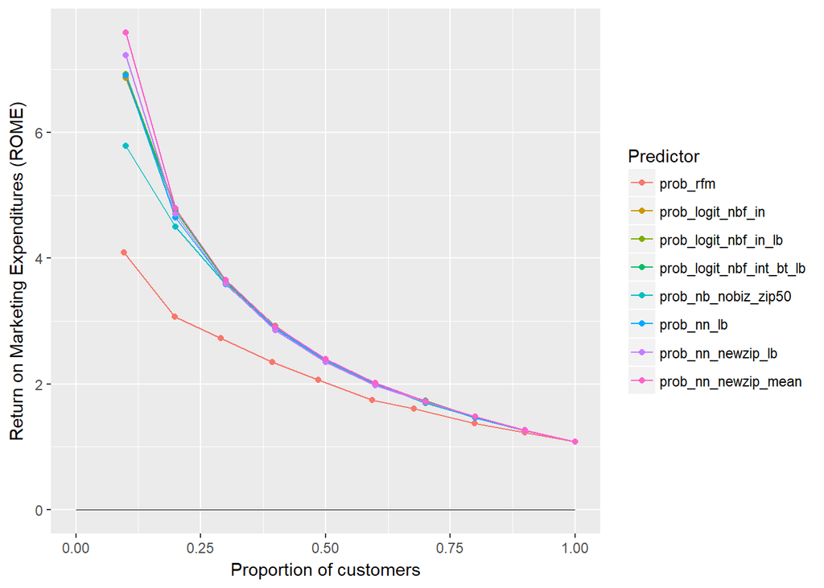

```r
plot(result, plots = c("lift", "gains", "profit", "rome"), custom = TRUE) #%>%
```

```r
#  gridExtra::grid.arrange(grobs = ., top = "Model evaluation", ncol = 2)

# Confusion matrix for different models
result <- confusion(
  dataset = "test",
  pred = c(
    "prob_rfm", "prob_logit_nbf_in","prob_logit_nbf_in_lb","prob_logit_nbf_in_ub","prob_logit_nbf_int_bt_lb",
    "prob_nb_nobiz_zip50", "prob_nn_lb","prob_nn_newzip_lb","prob_nn_newzip_mean"
  ),
  rvar = "res1",
  lev = "Yes",
  cost = 1.41,
  margin = 60,
  train = "All"
)
summary(result)
```

```
Confusion matrix
Data       : test
Results for: All
Predictors : prob_rfm, prob_logit_nbf_in, prob_logit_nbf_in_lb, prob_logit_nbf_in_ub, prob_logit_nbf_int_bt_lb, prob_nb_nobiz_zip50, prob_nn_lb, prob_nn_newzip_lb, prob_nn_newzip_mean
Response   : res1
Level      : Yes in res1
Cost:Margin: 1.41 : 60

 Type                Predictor   TP    FP    TN  FN total   TPR   TNR precision Fscore
  All                 prob_rfm 1033 18289  3108  70 22500 0.937 0.145     0.053  0.101
  All        prob_logit_nbf_in  980 13326  8071 123 22500 0.888 0.377     0.069  0.127
  All     prob_logit_nbf_in_lb  914 11237 10160 189 22500 0.829 0.475     0.075  0.138
  All     prob_logit_nbf_in_ub 1022 15346  6051  81 22500 0.927 0.283     0.062  0.117
  All prob_logit_nbf_int_bt_lb  908 11126 10271 195 22500 0.823 0.480     0.075  0.138
  All      prob_nb_nobiz_zip50  849  8937 12460 254 22500 0.770 0.582     0.087  0.156
  All               prob_nn_lb  977 13510  7887 126 22500 0.886 0.369     0.067  0.125
  All        prob_nn_newzip_lb  625  4215 17182 478 22500 0.567 0.803     0.129  0.210
  All      prob_nn_newzip_mean  948 12159  9238 155 22500 0.859 0.432     0.072  0.133

 Type                Predictor accuracy kappa profit index  ROME contact   AUC
  All                 prob_rfm    0.184 0.009 34,736 0.899 1.275   0.859 0.664
  All        prob_logit_nbf_in    0.402 0.040 38,629 1.000 1.915   0.636 0.755
  All     prob_logit_nbf_in_lb    0.492 0.053 37,707 0.976 2.201   0.540 0.755
  All     prob_logit_nbf_in_ub    0.314 0.028 38,241 0.990 1.657   0.727 0.754
  All prob_logit_nbf_int_bt_lb    0.497 0.053 37,512 0.971 2.211   0.535 0.754
  All      prob_nb_nobiz_zip50    0.592 0.074 37,142 0.962 2.692   0.435 0.739
  All               prob_nn_lb    0.394 0.038 38,193 0.989 1.870   0.644 0.751
  All        prob_nn_newzip_lb    0.791 0.142 30,676 0.794 4.495   0.215 0.755
  All      prob_nn_newzip_mean    0.453 0.047 38,399 0.994 2.078   0.583 0.761
```

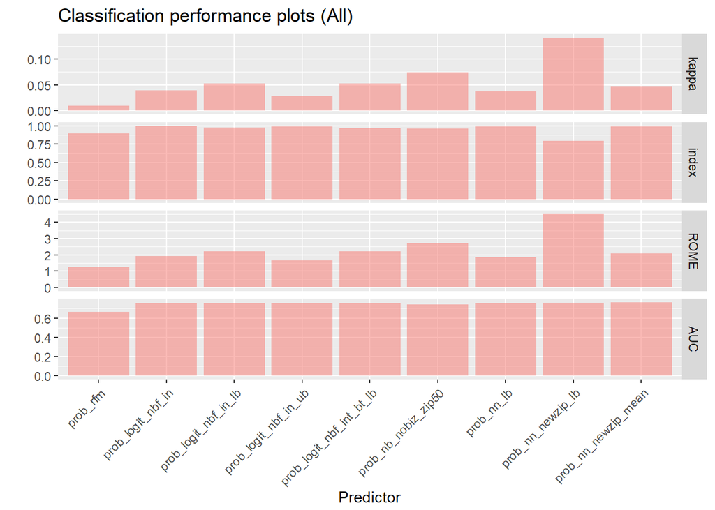

```r
plot(result) +
  theme(axis.text.x = element_text(angle = 45, hjust = 1))
```

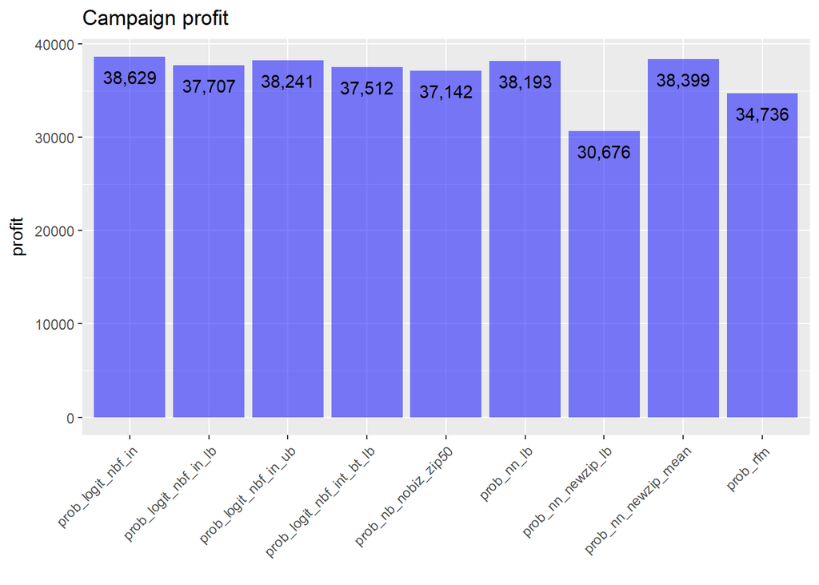

```r
# profit plot
compare <- result$dat
visualize(
  dataset = "compare",
  xvar = "Predictor",
  yvar = "profit",
  type = "bar",
  custom = TRUE
) +
  labs(title = "Campaign profit", x = "") +
  geom_text(aes(label = formatnr(profit, dec = 0)), vjust = 2) +
  theme(axis.text.x = element_text(angle = 45, hjust = 1))
```

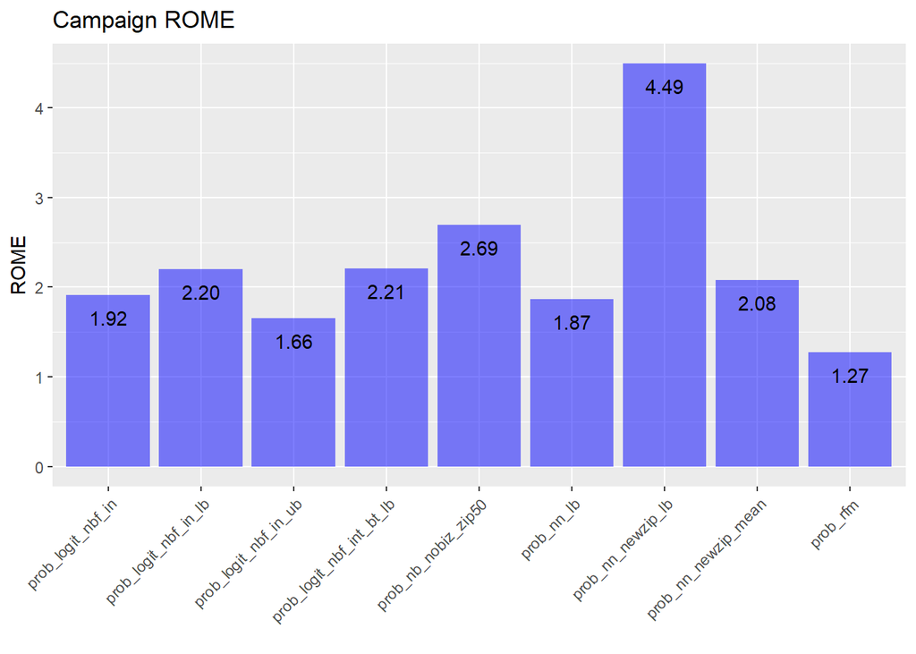

```r
# ROME plot
visualize(
  dataset = "compare",
  xvar = "Predictor",
  yvar = "ROME",
  type = "bar",
  custom = TRUE
) +
  labs(title = "Campaign ROME", x = "") +
  geom_text(aes(label = formatnr(ROME, dec = 2)), vjust = 2) +
  theme(axis.text.x = element_text(angle = 45, hjust = 1))
```

##### 11. Profit Calculation

```r
## Creating mailto columns
r_data[["test"]] <- r_data[["test"]] %>%
                    mutate(mailto_logit = factor(
                      ifelse( ( (prob_logit_nbf_in / 2) > BE_resp_rate), T, F),
                      levels = c(T, F))
  )

# Compute profit based on confusion matrix
table(r_data$test$res1, r_data$test$mailto_logit)
```

```
       TRUE FALSE
  Yes   746   357
  No   6171 15226
```

```r
# Expected profit from validation set
final_profit <- 746 * 60 - (746 + 6171) * 1.41

# generate mailto_wave 2 column
r_data[["test"]] <- r_data[["test"]] %>%
                    mutate(mailto_wave2 = factor(
                        ifelse( ( (prob_logit_nbf_in / 2) > BE_resp_rate) & res1 == "No", T, F),
                        levels = c(T, F))
)

saveRDS(r_data[["test"]]%>% select(id,mailto_wave2),"Lei_Qingqing_Xiaochen_Nehal_Group4.rds")

# scale profit to 801,821 businesses with 38,487 already responded
profit_scaled <-
  (final_profit / (nrow(r_data[["test"]]) - sum(r_data[["test"]][["res1"]] == "Yes")) )*(801821 - 38487)
```